# 贝叶斯统计

## 错误发现率（FDR）

- FDR可用来控制一个整体决策，保证整体犯错的概率低于某个数值，错误发现率越高，越可能把假阳性包括进来
- 假如我们把进入名人堂的决策作为一个整体，则可允许一定的整体错误率，因为每个人的后验错误率可以计算且期望值线性可加和，我们可以得到一个整体的错误率

```r
# 取前100个球员
top_players <- career_eb %>%
    arrange(PEP) %>%
    head(100)
# 总错率率
sum(top_players$PEP)
```

```
## [1] 4.69
```

```r
# 平均错误率
mean(top_players$PEP)
```

```
## [1] 0.0469
```

```r
# 错误率随所取球员的变化
sorted_PEP <- career_eb %>%
    arrange(PEP)

mean(head(sorted_PEP$PEP, 50))
```

```
## [1] 0.00113
```

```r
mean(head(sorted_PEP$PEP, 200))
```

```
## [1] 0.241
```

- 错误率在排序后前面低后面高，但这个错误率不特指某个球员，而是包含到某个球员的整体犯错的概率

## q值

- q值定义为排序后累积到某个样本的整体平均错误率，类似多重比较中对整体错误率控制的p值

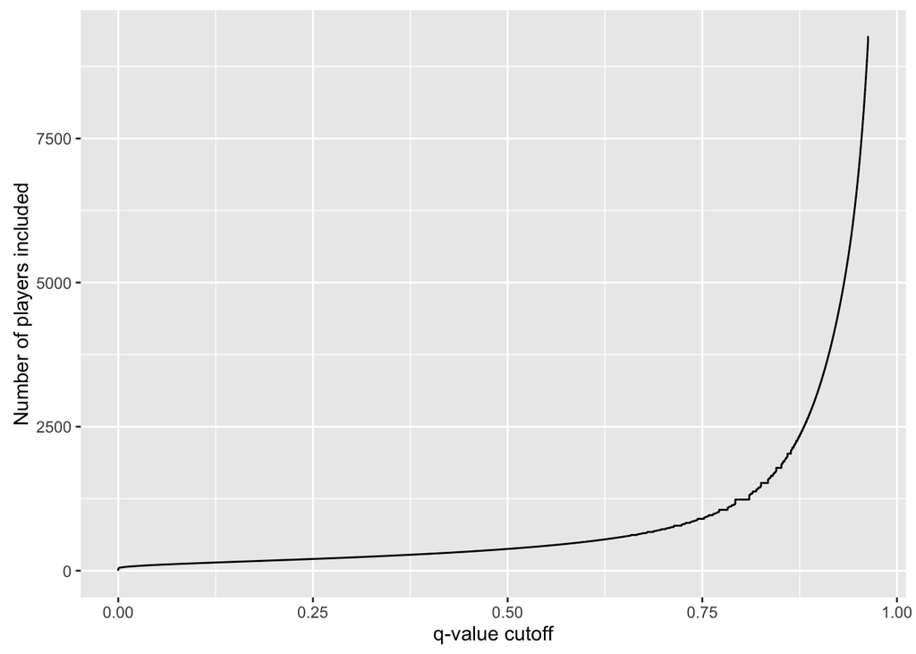

```r
# 生成每个球员的q值
career_eb <- career_eb %>%
    arrange(PEP) %>%
    mutate(qvalue = cummean(PEP))
# 观察不同q值对名人堂球员数的影响
career_eb %>%
    ggplot(aes(qvalue, rank(PEP))) +
    geom_line() +
    xlab("q-value cutoff") +
    ylab("Number of players included")
```

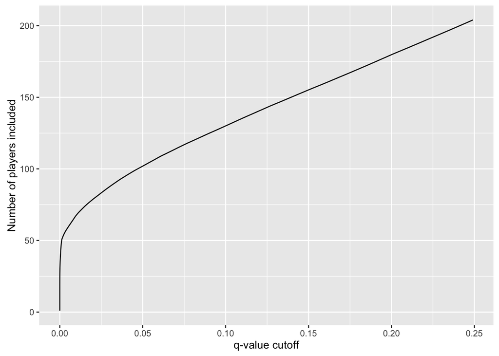

```r
# 观察小q值部分
career_eb %>%
    filter(qvalue < .25) %>%
    ggplot(aes(qvalue, rank(PEP))) +
    geom_line() +
    xlab("q-value cutoff") +
    ylab("Number of players included")
```

- 200个人进入名人堂可能有1/4的球员不合适，如果是50个人进入名人堂那么基本不会犯错
- q值是一个整体而非个体的平均错误率，具有累积性，不代表q值大的那一个就是错的
- q值在频率学派的多重比较里也有定义，虽然没有空假设（有先验概率），但实质等同